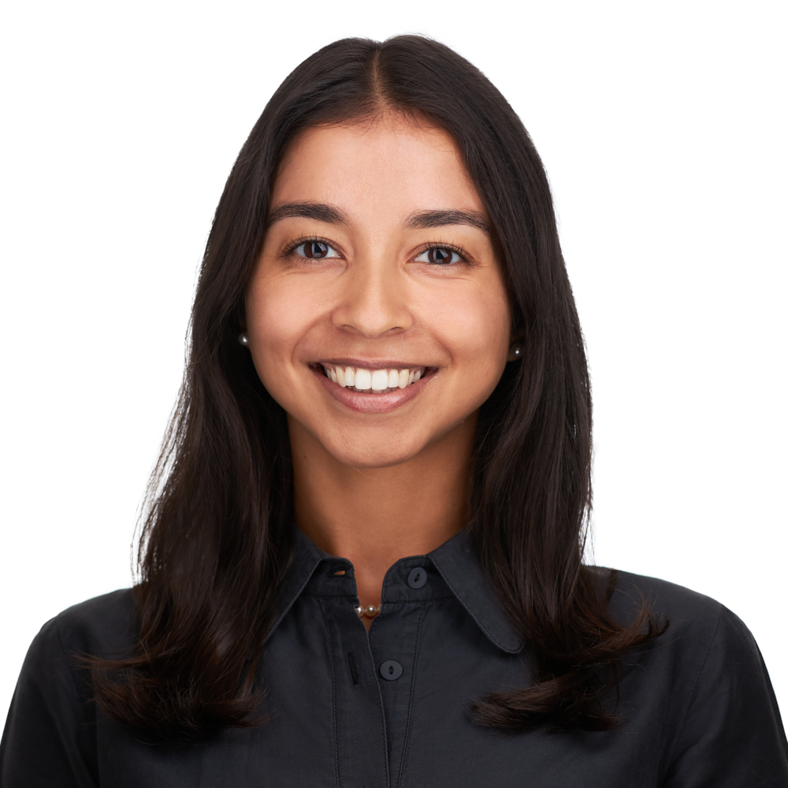

# Ilina Odouard

## Bio

Ilina Odouard is a Ph.D. student concentrating in health services research and policy in the Department of Health Policy and Management at the Johns Hopkins Bloomberg School of Public Health. Her research investigates pharmaceutical regulatory and payment strategies to promote affordability and equitable access while managing spending and maintaining adequate evidence quality. Currently, her research focuses on Medicare and Medicaid payment strategies for cell and gene therapies and investment in pharmaceutical innovation. Her work has been published in JAMA, JAMA Neurology, the Journal of Managed Care and Specialty Pharmacy, Value in Health, Health Affairs Scholar, and O&G Open. Prior to becoming an academic researcher, she was a life sciences and healthcare strategy consultant in both the United States and Australia.

## Education

**Johns Hopkins Bloomberg School of Public Health** | Baltimore, USA

M.P.H. | June 2022 - May 2023

**Barnard College of Columbia University** | New York, USA

B.A. in Neuroscience & Behavior | September 2014 - May 2018

## Experience

**Johns Hopkins Drug Access and Affordability Initiative** | Faculty Research Associate | Remote | May 2023 - August 2024

**Blue Matter Consulting** | Senior Consultant | New York, USA | September 2021 - May 2022

**Health Technology Analysts** | Senior Consultant | Sydney, Australia | March 2020 - May 2021

**IQVIA Consulting Services** | Associate | New York, USA | August 2018 - October 2019

## Skills

Claims data analysis, programming in R and Stata, literature review

## Publications

Markell J, **Odouard IC**, Anderson GF, DiStefano MJ. Consumer Perceptions of Safety Information in Direct-to-Consumer Print Advertisements for Alzheimer Drugs. *JAMA Netw Open.* 2024;7(8):e2431110. doi:10.1001/jamanetworkopen.2024.31110

Odouard IC, Ballreich J, Lee B, Socal MP. Clinical Evidence Supporting FDA Approval of Gene and RNA Therapies for Rare Inherited Conditions. *Pediatr Drugs*. 2024. https://doi.org/10.1007/s40272-024-00645-7

**Odouard IC**, Guadamuz JS, Chakraborty A, Alexander GC, Qato DM. Induced Abortion and Out-of-State Travel Among Insured Women Before and After the Dobbs v. Jackson Women’s Health Organization Decision. *O&G Open.* 2024;1(2):p 016. doi: 10.1097/og9.0000000000000016

**Odouard IC**, Ballreich J, Socal MP. Medicaid spending and utilization of gene and RNA therapies for rare inherited conditions. *Health Affairs Scholar*. 2024;2(5). doi: https://doi.org/10.1093/haschl/qxae051

Socal MP, **Odouard IC**, Kharrazi H. Ownership and Interoperability Challenges of Alzheimer Monoclonal Antibody Registries. *JAMA Neurol.* 2024;81(2):109–110. doi:10.1001/jamaneurol.2023.4675

**Odouard IC**, Anderson GF, Alexander GC, Ballreich J. Sociodemographic and spending characteristics of Medicare beneficiaries taking prescription drugs subject to price negotiations. *Journal of Managed Care & Specialty Pharmacy*. Published online Dec 23, 2023. doi:10.18553/jmcp.2023.23153

**Odouard IC**, Socal MP, Anderson GF. Role of Registries in Medicare Coverage of New Alzheimer Disease Drugs. *JAMA.* 2023;330(14):1331–1332. doi:10.1001/jama.2023.17131

DiStefano MJ, Levy JF, **Odouard IC**, Anderson GF. Estimated savings from using added therapeutic benefit and therapeutic reference pricing in United States Medicare drug price negotiations. *Value in Health*. 2023. doi:10.1016/j.jval.2023.08.004